# Risk Factor Analysis

## Outcome Variable

**Outcome Variable:** wasted

## Predictor Variables

**Intervention Variable:** perdiar6

**Adjustment Set:**

- arm
- sex
- W_mage
- meducyrs
- W_mhtcm
- W_mwtkg
- W_mbmi
- W_birthwt
- W_birthlen
- W_nrooms
- month
- brthmon
- impfloor
- impsan
- safeh20
- delta_W_mage
- delta_meducyrs
- delta_W_mhtcm
- delta_W_mwtkg
- delta_W_mbmi
- delta_W_birthwt
- delta_W_birthlen
- delta_W_nrooms
- delta_month
- delta_brthmon
- delta_impfloor
- delta_impsan
- delta_safeh20

## Stratifying Variables

The analysis was stratified on these variable(s):

- agecat
- studyid
- country

## Data Summary

| agecat | studyid | country | perdiar6 | wasted | n_cell | n |
| --- | --- | --- | --- | --- | --- | --- |
| Birth | ki0047075b-MAL-ED | BANGLADESH | 0% | 0 | 68 | 241 |
| Birth | ki0047075b-MAL-ED | BANGLADESH | 0% | 1 | 11 | 241 |
| Birth | ki0047075b-MAL-ED | BANGLADESH | (0%, 5%] | 0 | 75 | 241 |
| Birth | ki0047075b-MAL-ED | BANGLADESH | (0%, 5%] | 1 | 17 | 241 |
| Birth | ki0047075b-MAL-ED | BANGLADESH | >5% | 0 | 58 | 241 |
| Birth | ki0047075b-MAL-ED | BANGLADESH | >5% | 1 | 12 | 241 |
| Birth | ki0047075b-MAL-ED | BRAZIL | 0% | 0 | 164 | 183 |
| Birth | ki0047075b-MAL-ED | BRAZIL | 0% | 1 | 5 | 183 |
| Birth | ki0047075b-MAL-ED | BRAZIL | (0%, 5%] | 0 | 11 | 183 |
| Birth | ki0047075b-MAL-ED | BRAZIL | (0%, 5%] | 1 | 1 | 183 |
| Birth | ki0047075b-MAL-ED | BRAZIL | >5% | 0 | 2 | 183 |
| Birth | ki0047075b-MAL-ED | BRAZIL | >5% | 1 | 0 | 183 |
| Birth | ki0047075b-MAL-ED | INDIA | 0% | 0 | 39 | 203 |
| Birth | ki0047075b-MAL-ED | INDIA | 0% | 1 | 7 | 203 |
| Birth | ki0047075b-MAL-ED | INDIA | (0%, 5%] | 0 | 91 | 203 |
| Birth | ki0047075b-MAL-ED | INDIA | (0%, 5%] | 1 | 16 | 203 |
| Birth | ki0047075b-MAL-ED | INDIA | >5% | 0 | 40 | 203 |
| Birth | ki0047075b-MAL-ED | INDIA | >5% | 1 | 10 | 203 |
| Birth | ki0047075b-MAL-ED | NEPAL | 0% | 0 | 48 | 168 |
| Birth | ki0047075b-MAL-ED | NEPAL | 0% | 1 | 8 | 168 |
| Birth | ki0047075b-MAL-ED | NEPAL | (0%, 5%] | 0 | 51 | 168 |
| Birth | ki0047075b-MAL-ED | NEPAL | (0%, 5%] | 1 | 6 | 168 |
| Birth | ki0047075b-MAL-ED | NEPAL | >5% | 0 | 49 | 168 |
| Birth | ki0047075b-MAL-ED | NEPAL | >5% | 1 | 6 | 168 |
| Birth | ki0047075b-MAL-ED | PERU | 0% | 0 | 82 | 279 |
| Birth | ki0047075b-MAL-ED | PERU | 0% | 1 | 0 | 279 |
| Birth | ki0047075b-MAL-ED | PERU | (0%, 5%] | 0 | 83 | 279 |
| Birth | ki0047075b-MAL-ED | PERU | (0%, 5%] | 1 | 1 | 279 |
| Birth | ki0047075b-MAL-ED | PERU | >5% | 0 | 108 | 279 |
| Birth | ki0047075b-MAL-ED | PERU | >5% | 1 | 5 | 279 |

[output cut: 234 more lines]

The following strata were considered:

- agecat: 24 months, studyid: ki0047075b-MAL-ED, country: BANGLADESH
- agecat: 24 months, studyid: ki0047075b-MAL-ED, country: BRAZIL
- agecat: 24 months, studyid: ki0047075b-MAL-ED, country: INDIA
- agecat: 24 months, studyid: ki0047075b-MAL-ED, country: NEPAL
- agecat: 24 months, studyid: ki0047075b-MAL-ED, country: PERU
- agecat: 24 months, studyid: ki0047075b-MAL-ED, country: SOUTH AFRICA
- agecat: 24 months, studyid: ki0047075b-MAL-ED, country: TANZANIA, UNITED REPUBLIC OF
- agecat: 24 months, studyid: ki1017093-NIH-Birth, country: BANGLADESH
- agecat: 24 months, studyid: ki1017093b-PROVIDE, country: BANGLADESH
- agecat: 24 months, studyid: ki1017093c-NIH-Crypto, country: BANGLADESH
- agecat: 24 months, studyid: ki1114097-CMIN, country: BANGLADESH
- agecat: 24 months, studyid: ki1114097-CMIN, country: GUINEA-BISSAU
- agecat: 24 months, studyid: ki1114097-CMIN, country: PERU
- agecat: 24 months, studyid: ki1114097-CONTENT, country: PERU
- agecat: 6 months, studyid: ki0047075b-MAL-ED, country: BANGLADESH
- agecat: 6 months, studyid: ki0047075b-MAL-ED, country: BRAZIL
- agecat: 6 months, studyid: ki0047075b-MAL-ED, country: INDIA
- agecat: 6 months, studyid: ki0047075b-MAL-ED, country: NEPAL
- agecat: 6 months, studyid: ki0047075b-MAL-ED, country: PERU
- agecat: 6 months, studyid: ki0047075b-MAL-ED, country: SOUTH AFRICA
- agecat: 6 months, studyid: ki0047075b-MAL-ED, country: TANZANIA, UNITED REPUBLIC OF
- agecat: 6 months, studyid: ki1000109-ResPak, country: PAKISTAN
- agecat: 6 months, studyid: ki1017093-NIH-Birth, country: BANGLADESH
- agecat: 6 months, studyid: ki1017093b-PROVIDE, country: BANGLADESH
- agecat: 6 months, studyid: ki1017093c-NIH-Crypto, country: BANGLADESH
- agecat: 6 months, studyid: ki1114097-CMIN, country: BANGLADESH
- agecat: 6 months, studyid: ki1114097-CMIN, country: BRAZIL
- agecat: 6 months, studyid: ki1114097-CMIN, country: GUINEA-BISSAU
- agecat: 6 months, studyid: ki1114097-CMIN, country: PERU
- agecat: 6 months, studyid: ki1114097-CONTENT, country: PERU
- agecat: Birth, studyid: ki0047075b-MAL-ED, country: BANGLADESH
- agecat: Birth, studyid: ki0047075b-MAL-ED, country: BRAZIL
- agecat: Birth, studyid: ki0047075b-MAL-ED, country: INDIA
- agecat: Birth, studyid: ki0047075b-MAL-ED, country: NEPAL
- agecat: Birth, studyid: ki0047075b-MAL-ED, country: PERU
- agecat: Birth, studyid: ki0047075b-MAL-ED, country: SOUTH AFRICA
- agecat: Birth, studyid: ki0047075b-MAL-ED, country: TANZANIA, UNITED REPUBLIC OF
- agecat: Birth, studyid: ki1000109-ResPak, country: PAKISTAN
- agecat: Birth, studyid: ki1017093-NIH-Birth, country: BANGLADESH
- agecat: Birth, studyid: ki1017093c-NIH-Crypto, country: BANGLADESH
- agecat: Birth, studyid: ki1114097-CMIN, country: BANGLADESH
- agecat: Birth, studyid: ki1114097-CMIN, country: BRAZIL
- agecat: Birth, studyid: ki1114097-CMIN, country: PERU
- agecat: Birth, studyid: ki1114097-CONTENT, country: PERU

### Dropped Strata

Some strata were dropped due to rare outcomes:

- agecat: Birth, studyid: ki0047075b-MAL-ED, country: BRAZIL
- agecat: Birth, studyid: ki0047075b-MAL-ED, country: PERU
- agecat: Birth, studyid: ki0047075b-MAL-ED, country: SOUTH AFRICA
- agecat: Birth, studyid: ki0047075b-MAL-ED, country: TANZANIA, UNITED REPUBLIC OF
- agecat: Birth, studyid: ki1000109-ResPak, country: PAKISTAN
- agecat: Birth, studyid: ki1017093-NIH-Birth, country: BANGLADESH
- agecat: Birth, studyid: ki1017093c-NIH-Crypto, country: BANGLADESH
- agecat: Birth, studyid: ki1114097-CMIN, country: BANGLADESH
- agecat: Birth, studyid: ki1114097-CMIN, country: BRAZIL
- agecat: Birth, studyid: ki1114097-CMIN, country: PERU
- agecat: Birth, studyid: ki1114097-CONTENT, country: PERU
- agecat: 6 months, studyid: ki0047075b-MAL-ED, country: BANGLADESH
- agecat: 6 months, studyid: ki0047075b-MAL-ED, country: BRAZIL
- agecat: 6 months, studyid: ki0047075b-MAL-ED, country: INDIA
- agecat: 6 months, studyid: ki0047075b-MAL-ED, country: NEPAL
- agecat: 6 months, studyid: ki0047075b-MAL-ED, country: PERU
- agecat: 6 months, studyid: ki0047075b-MAL-ED, country: SOUTH AFRICA
- agecat: 6 months, studyid: ki0047075b-MAL-ED, country: TANZANIA, UNITED REPUBLIC OF
- agecat: 6 months, studyid: ki1017093c-NIH-Crypto, country: BANGLADESH
- agecat: 6 months, studyid: ki1114097-CMIN, country: BANGLADESH
- agecat: 6 months, studyid: ki1114097-CMIN, country: BRAZIL
- agecat: 6 months, studyid: ki1114097-CMIN, country: PERU
- agecat: 6 months, studyid: ki1114097-CONTENT, country: PERU
- agecat: 24 months, studyid: ki0047075b-MAL-ED, country: BRAZIL
- agecat: 24 months, studyid: ki0047075b-MAL-ED, country: NEPAL
- agecat: 24 months, studyid: ki0047075b-MAL-ED, country: PERU
- agecat: 24 months, studyid: ki0047075b-MAL-ED, country: SOUTH AFRICA
- agecat: 24 months, studyid: ki0047075b-MAL-ED, country: TANZANIA, UNITED REPUBLIC OF
- agecat: 24 months, studyid: ki1114097-CMIN, country: BANGLADESH
- agecat: 24 months, studyid: ki1114097-CMIN, country: GUINEA-BISSAU
- agecat: 24 months, studyid: ki1114097-CMIN, country: PERU
- agecat: 24 months, studyid: ki1114097-CONTENT, country: PERU

## Methods Detail

We’re interested in the causal parameters $E[Y_a]$ for all values of $a \in \mathcal{A}$. These parameters represent the mean outcome if, possibly contrary to fact, we intervened to set all units to have $A=a$. Under the randomization and positivity assumptions, these are identified by the statistical parameters $\psi_a=E_W[E_{Y|A,W}(Y|A=a,W)]$. In addition, we’re interested in the mean of $Y$, $E[Y]$ under no intervention (the observed mean). We will estimate these parameters by using SuperLearner to fit the relevant likelihood factors – $E_{Y|A,W}(Y|A=a,W)$ and $p(A=a|W)$, and then updating our likelihood fit using a joint TMLE.

For unadjusted analyses ($W=\{\}$), initial likelihoods were estimated using Lrnr_glm to estimate the simple $E(Y|A)$ and Lrnr_mean to estimate $p(A)$. For adjusted analyses, a small library containing Lrnr_glmnet, Lrnr_xgboost, and Lrnr_mean was used.

Having estimated these parameters, we will then use the delta method to estimate relative risks and attributable risks relative to a prespecified baseline level of $A$.

# Results Detail

## Results Plots

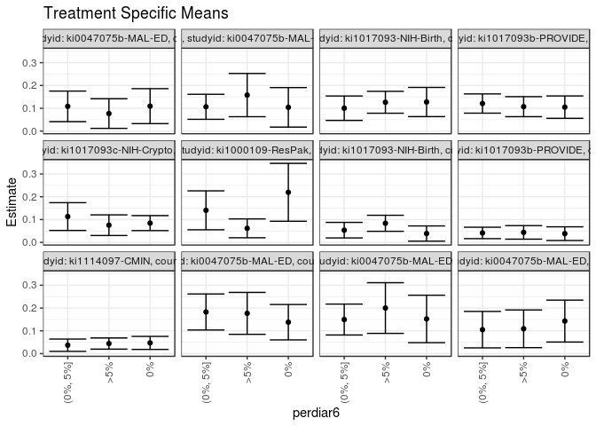

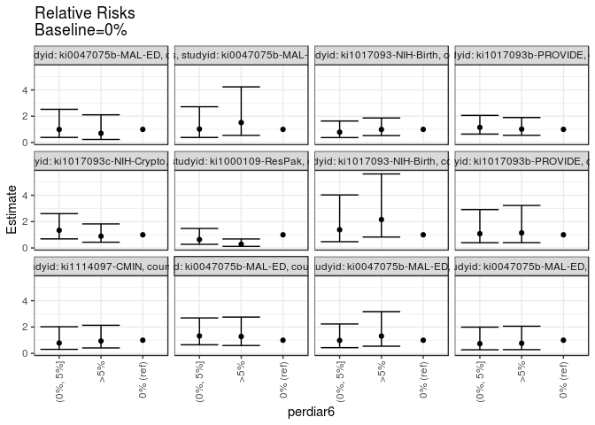

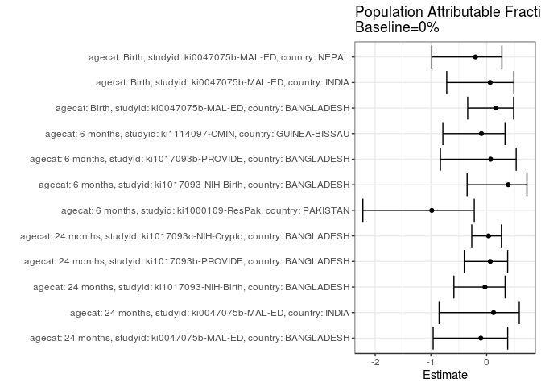

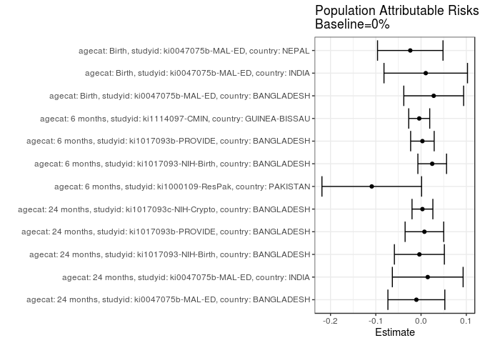

## Results Table

### Parameter: TSM

| agecat | studyid | country | intervention_level | baseline_level | estimate | ci_lower | ci_upper |
| --- | --- | --- | --- | --- | --- | --- | --- |
| Birth | ki0047075b-MAL-ED | BANGLADESH | 0% | NA | 0.1379971 | 0.0604220 | 0.2155723 |
| Birth | ki0047075b-MAL-ED | BANGLADESH | (0%, 5%] | NA | 0.1826686 | 0.1036123 | 0.2617248 |
| Birth | ki0047075b-MAL-ED | BANGLADESH | >5% | NA | 0.1767127 | 0.0848063 | 0.2686190 |
| Birth | ki0047075b-MAL-ED | INDIA | 0% | NA | 0.1521739 | 0.0481184 | 0.2562294 |
| Birth | ki0047075b-MAL-ED | INDIA | (0%, 5%] | NA | 0.1495327 | 0.0817958 | 0.2172696 |
| Birth | ki0047075b-MAL-ED | INDIA | >5% | NA | 0.2000000 | 0.0888536 | 0.3111464 |
| Birth | ki0047075b-MAL-ED | NEPAL | 0% | NA | 0.1428571 | 0.0509333 | 0.2347810 |
| Birth | ki0047075b-MAL-ED | NEPAL | (0%, 5%] | NA | 0.1052632 | 0.0253547 | 0.1851716 |
| Birth | ki0047075b-MAL-ED | NEPAL | >5% | NA | 0.1090909 | 0.0264540 | 0.1917278 |
| 6 months | ki1000109-ResPak | PAKISTAN | 0% | NA | 0.2195122 | 0.0925441 | 0.3464803 |
| 6 months | ki1000109-ResPak | PAKISTAN | (0%, 5%] | NA | 0.1406250 | 0.0552744 | 0.2259756 |
| 6 months | ki1000109-ResPak | PAKISTAN | >5% | NA | 0.0615385 | 0.0201400 | 0.1029369 |
| 6 months | ki1017093-NIH-Birth | BANGLADESH | 0% | NA | 0.0387597 | 0.0054198 | 0.0720996 |
| 6 months | ki1017093-NIH-Birth | BANGLADESH | (0%, 5%] | NA | 0.0535714 | 0.0194907 | 0.0876522 |
| 6 months | ki1017093-NIH-Birth | BANGLADESH | >5% | NA | 0.0836820 | 0.0485427 | 0.1188214 |
| 6 months | ki1017093b-PROVIDE | BANGLADESH | 0% | NA | 0.0382166 | 0.0082017 | 0.0682314 |
| 6 months | ki1017093b-PROVIDE | BANGLADESH | (0%, 5%] | NA | 0.0413223 | 0.0162241 | 0.0664205 |
| 6 months | ki1017093b-PROVIDE | BANGLADESH | >5% | NA | 0.0437158 | 0.0140669 | 0.0733648 |
| 6 months | ki1114097-CMIN | GUINEA-BISSAU | 0% | NA | 0.0471698 | 0.0186108 | 0.0757288 |
| 6 months | ki1114097-CMIN | GUINEA-BISSAU | (0%, 5%] | NA | 0.0370370 | 0.0100929 | 0.0639811 |
| 6 months | ki1114097-CMIN | GUINEA-BISSAU | >5% | NA | 0.0442804 | 0.0197696 | 0.0687913 |
| 24 months | ki0047075b-MAL-ED | BANGLADESH | 0% | NA | 0.1093750 | 0.0327287 | 0.1860213 |
| 24 months | ki0047075b-MAL-ED | BANGLADESH | (0%, 5%] | NA | 0.1084337 | 0.0413844 | 0.1754831 |
| 24 months | ki0047075b-MAL-ED | BANGLADESH | >5% | NA | 0.0769231 | 0.0119901 | 0.1418561 |
| 24 months | ki0047075b-MAL-ED | INDIA | 0% | NA | 0.1041667 | 0.0175574 | 0.1907759 |
| 24 months | ki0047075b-MAL-ED | INDIA | (0%, 5%] | NA | 0.1065574 | 0.0516852 | 0.1614295 |
| 24 months | ki0047075b-MAL-ED | INDIA | >5% | NA | 0.1578947 | 0.0630231 | 0.2527664 |
| 24 months | ki1017093-NIH-Birth | BANGLADESH | 0% | NA | 0.1274994 | 0.0634979 | 0.1915009 |
| 24 months | ki1017093-NIH-Birth | BANGLADESH | (0%, 5%] | NA | 0.1003490 | 0.0468689 | 0.1538291 |
| 24 months | ki1017093-NIH-Birth | BANGLADESH | >5% | NA | 0.1263310 | 0.0783281 | 0.1743340 |
| 24 months | ki1017093b-PROVIDE | BANGLADESH | 0% | NA | 0.1050253 | 0.0558952 | 0.1541555 |
| 24 months | ki1017093b-PROVIDE | BANGLADESH | (0%, 5%] | NA | 0.1207389 | 0.0785828 | 0.1628951 |
| 24 months | ki1017093b-PROVIDE | BANGLADESH | >5% | NA | 0.1071153 | 0.0631732 | 0.1510574 |
| 24 months | ki1017093c-NIH-Crypto | BANGLADESH | 0% | NA | 0.0844549 | 0.0515129 | 0.1173969 |
| 24 months | ki1017093c-NIH-Crypto | BANGLADESH | (0%, 5%] | NA | 0.1131268 | 0.0522088 | 0.1740449 |
| 24 months | ki1017093c-NIH-Crypto | BANGLADESH | >5% | NA | 0.0753415 | 0.0301251 | 0.1205580 |

### Parameter: E(Y)

| agecat | studyid | country | intervention_level | baseline_level | estimate | ci_lower | ci_upper |
| --- | --- | --- | --- | --- | --- | --- | --- |
| Birth | ki0047075b-MAL-ED | BANGLADESH | NA | NA | 0.1659751 | 0.1189041 | 0.2130461 |
| Birth | ki0047075b-MAL-ED | INDIA | NA | NA | 0.1625616 | 0.1116803 | 0.2134428 |
| Birth | ki0047075b-MAL-ED | NEPAL | NA | NA | 0.1190476 | 0.0699312 | 0.1681640 |
| 6 months | ki1000109-ResPak | PAKISTAN | NA | NA | 0.1106383 | 0.0704470 | 0.1508296 |
| 6 months | ki1017093-NIH-Birth | BANGLADESH | NA | NA | 0.0634328 | 0.0427791 | 0.0840865 |
| 6 months | ki1017093b-PROVIDE | BANGLADESH | NA | NA | 0.0412371 | 0.0250690 | 0.0574052 |
| 6 months | ki1114097-CMIN | GUINEA-BISSAU | NA | NA | 0.0431548 | 0.0277795 | 0.0585300 |
| 24 months | ki0047075b-MAL-ED | BANGLADESH | NA | NA | 0.0990566 | 0.0587480 | 0.1393652 |
| 24 months | ki0047075b-MAL-ED | INDIA | NA | NA | 0.1189427 | 0.0767376 | 0.1611478 |
| 24 months | ki1017093-NIH-Birth | BANGLADESH | NA | NA | 0.1238318 | 0.0925894 | 0.1550741 |
| 24 months | ki1017093b-PROVIDE | BANGLADESH | NA | NA | 0.1124567 | 0.0866788 | 0.1382347 |
| 24 months | ki1017093c-NIH-Crypto | BANGLADESH | NA | NA | 0.0875486 | 0.0630907 | 0.1120065 |

### Parameter: RR

| agecat | studyid | country | intervention_level | baseline_level | estimate | ci_lower | ci_upper |
| --- | --- | --- | --- | --- | --- | --- | --- |
| Birth | ki0047075b-MAL-ED | BANGLADESH | 0% | 0% | 1.0000000 | 1.0000000 | 1.0000000 |
| Birth | ki0047075b-MAL-ED | BANGLADESH | (0%, 5%] | 0% | 1.3237125 | 0.6510597 | 2.6913274 |
| Birth | ki0047075b-MAL-ED | BANGLADESH | >5% | 0% | 1.2805530 | 0.5952324 | 2.7549172 |
| Birth | ki0047075b-MAL-ED | INDIA | 0% | 0% | 1.0000000 | 1.0000000 | 1.0000000 |
| Birth | ki0047075b-MAL-ED | INDIA | (0%, 5%] | 0% | 0.9826435 | 0.4326887 | 2.2316003 |
| Birth | ki0047075b-MAL-ED | INDIA | >5% | 0% | 1.3142857 | 0.5445210 | 3.1722317 |
| Birth | ki0047075b-MAL-ED | NEPAL | 0% | 0% | 1.0000000 | 1.0000000 | 1.0000000 |
| Birth | ki0047075b-MAL-ED | NEPAL | (0%, 5%] | 0% | 0.7368421 | 0.2723862 | 1.9932590 |
| Birth | ki0047075b-MAL-ED | NEPAL | >5% | 0% | 0.7636364 | 0.2826413 | 2.0631824 |
| 6 months | ki1000109-ResPak | PAKISTAN | 0% | 0% | 1.0000000 | 1.0000000 | 1.0000000 |
| 6 months | ki1000109-ResPak | PAKISTAN | (0%, 5%] | 0% | 0.6406250 | 0.2770046 | 1.4815655 |
| 6 months | ki1000109-ResPak | PAKISTAN | >5% | 0% | 0.2803419 | 0.1154473 | 0.6807573 |
| 6 months | ki1017093-NIH-Birth | BANGLADESH | 0% | 0% | 1.0000000 | 1.0000000 | 1.0000000 |
| 6 months | ki1017093-NIH-Birth | BANGLADESH | (0%, 5%] | 0% | 1.3821426 | 0.4741507 | 4.0289261 |
| 6 months | ki1017093-NIH-Birth | BANGLADESH | >5% | 0% | 2.1589953 | 0.8289861 | 5.6228454 |
| 6 months | ki1017093b-PROVIDE | BANGLADESH | 0% | 0% | 1.0000000 | 1.0000000 | 1.0000000 |
| 6 months | ki1017093b-PROVIDE | BANGLADESH | (0%, 5%] | 0% | 1.0812672 | 0.4006323 | 2.9182340 |
| 6 months | ki1017093b-PROVIDE | BANGLADESH | >5% | 0% | 1.1438980 | 0.4052481 | 3.2288928 |
| 6 months | ki1114097-CMIN | GUINEA-BISSAU | 0% | 0% | 1.0000000 | 1.0000000 | 1.0000000 |
| 6 months | ki1114097-CMIN | GUINEA-BISSAU | (0%, 5%] | 0% | 0.7851852 | 0.3047359 | 2.0231153 |
| 6 months | ki1114097-CMIN | GUINEA-BISSAU | >5% | 0% | 0.9387454 | 0.4133086 | 2.1321668 |
| 24 months | ki0047075b-MAL-ED | BANGLADESH | 0% | 0% | 1.0000000 | 1.0000000 | 1.0000000 |
| 24 months | ki0047075b-MAL-ED | BANGLADESH | (0%, 5%] | 0% | 0.9913941 | 0.3893743 | 2.5242096 |
| 24 months | ki0047075b-MAL-ED | BANGLADESH | >5% | 0% | 0.7032967 | 0.2347872 | 2.1067003 |
| 24 months | ki0047075b-MAL-ED | INDIA | 0% | 0% | 1.0000000 | 1.0000000 | 1.0000000 |
| 24 months | ki0047075b-MAL-ED | INDIA | (0%, 5%] | 0% | 1.0229508 | 0.3846933 | 2.7201625 |
| 24 months | ki0047075b-MAL-ED | INDIA | >5% | 0% | 1.5157895 | 0.5434074 | 4.2281676 |
| 24 months | ki1017093-NIH-Birth | BANGLADESH | 0% | 0% | 1.0000000 | 1.0000000 | 1.0000000 |
| 24 months | ki1017093-NIH-Birth | BANGLADESH | (0%, 5%] | 0% | 0.7870547 | 0.3787768 | 1.6354095 |
| 24 months | ki1017093-NIH-Birth | BANGLADESH | >5% | 0% | 0.9908364 | 0.5266515 | 1.8641489 |
| 24 months | ki1017093b-PROVIDE | BANGLADESH | 0% | 0% | 1.0000000 | 1.0000000 | 1.0000000 |
| 24 months | ki1017093b-PROVIDE | BANGLADESH | (0%, 5%] | 0% | 1.1496174 | 0.6410726 | 2.0615762 |
| 24 months | ki1017093b-PROVIDE | BANGLADESH | >5% | 0% | 1.0198998 | 0.5474026 | 1.9002387 |
| 24 months | ki1017093c-NIH-Crypto | BANGLADESH | 0% | 0% | 1.0000000 | 1.0000000 | 1.0000000 |
| 24 months | ki1017093c-NIH-Crypto | BANGLADESH | (0%, 5%] | 0% | 1.3394938 | 0.6886415 | 2.6054831 |
| 24 months | ki1017093c-NIH-Crypto | BANGLADESH | >5% | 0% | 0.8920915 | 0.4358883 | 1.8257598 |

### Parameter: PAR

| agecat | studyid | country | intervention_level | baseline_level | estimate | ci_lower | ci_upper |
| --- | --- | --- | --- | --- | --- | --- | --- |
| Birth | ki0047075b-MAL-ED | BANGLADESH | 0% | NA | 0.0279780 | -0.0381011 | 0.0940570 |
| Birth | ki0047075b-MAL-ED | INDIA | 0% | NA | 0.0103877 | -0.0818586 | 0.1026340 |
| Birth | ki0047075b-MAL-ED | NEPAL | 0% | NA | -0.0238095 | -0.0961219 | 0.0485029 |
| 6 months | ki1000109-ResPak | PAKISTAN | 0% | NA | -0.1088739 | -0.2189242 | 0.0011764 |
| 6 months | ki1017093-NIH-Birth | BANGLADESH | 0% | NA | 0.0246731 | -0.0069984 | 0.0563447 |
| 6 months | ki1017093b-PROVIDE | BANGLADESH | 0% | NA | 0.0030206 | -0.0229843 | 0.0290254 |
| 6 months | ki1114097-CMIN | GUINEA-BISSAU | 0% | NA | -0.0040150 | -0.0271969 | 0.0191668 |
| 24 months | ki0047075b-MAL-ED | BANGLADESH | 0% | NA | -0.0103184 | -0.0731871 | 0.0525503 |
| 24 months | ki0047075b-MAL-ED | INDIA | 0% | NA | 0.0147761 | -0.0633913 | 0.0929434 |
| 24 months | ki1017093-NIH-Birth | BANGLADESH | 0% | NA | -0.0036676 | -0.0588728 | 0.0515376 |
| 24 months | ki1017093b-PROVIDE | BANGLADESH | 0% | NA | 0.0074314 | -0.0352083 | 0.0500711 |
| 24 months | ki1017093c-NIH-Crypto | BANGLADESH | 0% | NA | 0.0030937 | -0.0199292 | 0.0261166 |

### Parameter: PAF

| agecat | studyid | country | intervention_level | baseline_level | estimate | ci_lower | ci_upper |
| --- | --- | --- | --- | --- | --- | --- | --- |
| Birth | ki0047075b-MAL-ED | BANGLADESH | 0% | NA | 0.1685672 | -0.3397360 | 0.4840174 |
| Birth | ki0047075b-MAL-ED | INDIA | 0% | NA | 0.0638999 | -0.7158653 | 0.4893052 |
| Birth | ki0047075b-MAL-ED | NEPAL | 0% | NA | -0.2000000 | -0.9844517 | 0.2743588 |
| 6 months | ki1000109-ResPak | PAKISTAN | 0% | NA | -0.9840525 | -2.2213831 | -0.2219796 |
| 6 months | ki1017093-NIH-Birth | BANGLADESH | 0% | NA | 0.3889648 | -0.3499240 | 0.7234185 |
| 6 months | ki1017093b-PROVIDE | BANGLADESH | 0% | NA | 0.0732484 | -0.8289473 | 0.5304028 |
| 6 months | ki1114097-CMIN | GUINEA-BISSAU | 0% | NA | -0.0930384 | -0.7852764 | 0.3307855 |
| 24 months | ki0047075b-MAL-ED | BANGLADESH | 0% | NA | -0.1041667 | -0.9599502 | 0.3779515 |
| 24 months | ki0047075b-MAL-ED | INDIA | 0% | NA | 0.1242284 | -0.8523711 | 0.5859491 |
| 24 months | ki1017093-NIH-Birth | BANGLADESH | 0% | NA | -0.0296175 | -0.5873715 | 0.3321588 |
| 24 months | ki1017093b-PROVIDE | BANGLADESH | 0% | NA | 0.0660825 | -0.4013596 | 0.3776030 |
| 24 months | ki1017093c-NIH-Crypto | BANGLADESH | 0% | NA | 0.0353371 | -0.2667191 | 0.2653663 |